# Risk Factor Analysis

## Outcome Variable

**Outcome Variable:** wast_rec90d

## Predictor Variables

**Intervention Variable:** exclfeed3

**Adjustment Set:**

- arm
- sex
- brthmon
- W_mage
- meducyrs
- feducyrs
- hhwealth_quart
- hfoodsec
- W_mhtcm
- W_mwtkg
- W_mbmi
- vagbrth
- W_gagebrth
- W_birthwt
- W_birthlen
- W_nrooms
- W_nchldlt5
- month
- W_parity
- impfloor
- impsan
- safeh20
- delta_W_mage
- delta_meducyrs
- delta_feducyrs
- delta_hhwealth_quart
- delta_hfoodsec
- delta_W_mhtcm
- delta_W_mwtkg
- delta_W_mbmi
- delta_vagbrth
- delta_W_gagebrth
- delta_W_birthwt
- delta_W_birthlen
- delta_W_nrooms
- delta_W_nchldlt5
- delta_month
- delta_W_parity
- delta_impfloor
- delta_impsan
- delta_safeh20

## Stratifying Variables

The analysis was stratified on these variable(s):

- agecat
- studyid
- country

## Data Summary

| agecat | studyid | country | exclfeed3 | wast_rec90d | n_cell | n |
| --- | --- | --- | --- | --- | --- | --- |
| 0-24 months | CMC-V-BCS-2002 | INDIA | 1 | 0 | 5 | 11 |
| 0-24 months | CMC-V-BCS-2002 | INDIA | 1 | 1 | 6 | 11 |
| 0-24 months | CMC-V-BCS-2002 | INDIA | 0 | 0 | 0 | 11 |
| 0-24 months | CMC-V-BCS-2002 | INDIA | 0 | 1 | 0 | 11 |
| 0-24 months | EE | PAKISTAN | 1 | 0 | 14 | 30 |
| 0-24 months | EE | PAKISTAN | 1 | 1 | 16 | 30 |
| 0-24 months | EE | PAKISTAN | 0 | 0 | 0 | 30 |
| 0-24 months | EE | PAKISTAN | 0 | 1 | 0 | 30 |
| 0-24 months | GMS-Nepal | NEPAL | 1 | 0 | 185 | 491 |
| 0-24 months | GMS-Nepal | NEPAL | 1 | 1 | 231 | 491 |
| 0-24 months | GMS-Nepal | NEPAL | 0 | 0 | 32 | 491 |
| 0-24 months | GMS-Nepal | NEPAL | 0 | 1 | 43 | 491 |
| 0-24 months | IRC | INDIA | 1 | 0 | 0 | 14 |
| 0-24 months | IRC | INDIA | 1 | 1 | 0 | 14 |
| 0-24 months | IRC | INDIA | 0 | 0 | 8 | 14 |
| 0-24 months | IRC | INDIA | 0 | 1 | 6 | 14 |
| 0-24 months | JiVitA-3 | BANGLADESH | 1 | 0 | 2251 | 4340 |
| 0-24 months | JiVitA-3 | BANGLADESH | 1 | 1 | 1698 | 4340 |
| 0-24 months | JiVitA-3 | BANGLADESH | 0 | 0 | 219 | 4340 |
| 0-24 months | JiVitA-3 | BANGLADESH | 0 | 1 | 172 | 4340 |
| 0-24 months | JiVitA-4 | BANGLADESH | 1 | 0 | 37 | 54 |
| 0-24 months | JiVitA-4 | BANGLADESH | 1 | 1 | 12 | 54 |
| 0-24 months | JiVitA-4 | BANGLADESH | 0 | 0 | 5 | 54 |
| 0-24 months | JiVitA-4 | BANGLADESH | 0 | 1 | 0 | 54 |
| 0-24 months | Keneba | GAMBIA | 1 | 0 | 456 | 1502 |
| 0-24 months | Keneba | GAMBIA | 1 | 1 | 849 | 1502 |
| 0-24 months | Keneba | GAMBIA | 0 | 0 | 82 | 1502 |
| 0-24 months | Keneba | GAMBIA | 0 | 1 | 115 | 1502 |
| 0-24 months | MAL-ED | BANGLADESH | 1 | 0 | 26 | 117 |
| 0-24 months | MAL-ED | BANGLADESH | 1 | 1 | 51 | 117 |

[output cut: 162 more lines]

The following strata were considered:

- agecat: 0-24 months, studyid: CMC-V-BCS-2002, country: INDIA
- agecat: 0-24 months, studyid: EE, country: PAKISTAN
- agecat: 0-24 months, studyid: GMS-Nepal, country: NEPAL
- agecat: 0-24 months, studyid: IRC, country: INDIA
- agecat: 0-24 months, studyid: JiVitA-3, country: BANGLADESH
- agecat: 0-24 months, studyid: JiVitA-4, country: BANGLADESH
- agecat: 0-24 months, studyid: Keneba, country: GAMBIA
- agecat: 0-24 months, studyid: MAL-ED, country: BANGLADESH
- agecat: 0-24 months, studyid: MAL-ED, country: BRAZIL
- agecat: 0-24 months, studyid: MAL-ED, country: INDIA
- agecat: 0-24 months, studyid: MAL-ED, country: NEPAL
- agecat: 0-24 months, studyid: MAL-ED, country: PERU
- agecat: 0-24 months, studyid: MAL-ED, country: SOUTH AFRICA
- agecat: 0-24 months, studyid: MAL-ED, country: TANZANIA, UNITED REPUBLIC OF
- agecat: 0-24 months, studyid: PROVIDE, country: BANGLADESH
- agecat: 0-24 months, studyid: SAS-CompFeed, country: INDIA
- agecat: 0-6 months, studyid: CMC-V-BCS-2002, country: INDIA
- agecat: 0-6 months, studyid: EE, country: PAKISTAN
- agecat: 0-6 months, studyid: GMS-Nepal, country: NEPAL
- agecat: 0-6 months, studyid: IRC, country: INDIA
- agecat: 0-6 months, studyid: JiVitA-3, country: BANGLADESH
- agecat: 0-6 months, studyid: JiVitA-4, country: BANGLADESH
- agecat: 0-6 months, studyid: Keneba, country: GAMBIA
- agecat: 0-6 months, studyid: MAL-ED, country: BANGLADESH
- agecat: 0-6 months, studyid: MAL-ED, country: BRAZIL
- agecat: 0-6 months, studyid: MAL-ED, country: INDIA
- agecat: 0-6 months, studyid: MAL-ED, country: NEPAL
- agecat: 0-6 months, studyid: MAL-ED, country: PERU
- agecat: 0-6 months, studyid: MAL-ED, country: SOUTH AFRICA
- agecat: 0-6 months, studyid: MAL-ED, country: TANZANIA, UNITED REPUBLIC OF
- agecat: 0-6 months, studyid: PROVIDE, country: BANGLADESH
- agecat: 0-6 months, studyid: SAS-CompFeed, country: INDIA
- agecat: 6-24 months, studyid: CMC-V-BCS-2002, country: INDIA
- agecat: 6-24 months, studyid: EE, country: PAKISTAN
- agecat: 6-24 months, studyid: GMS-Nepal, country: NEPAL
- agecat: 6-24 months, studyid: IRC, country: INDIA
- agecat: 6-24 months, studyid: JiVitA-3, country: BANGLADESH
- agecat: 6-24 months, studyid: JiVitA-4, country: BANGLADESH
- agecat: 6-24 months, studyid: Keneba, country: GAMBIA
- agecat: 6-24 months, studyid: MAL-ED, country: BANGLADESH
- agecat: 6-24 months, studyid: MAL-ED, country: BRAZIL
- agecat: 6-24 months, studyid: MAL-ED, country: INDIA
- agecat: 6-24 months, studyid: MAL-ED, country: NEPAL
- agecat: 6-24 months, studyid: MAL-ED, country: PERU
- agecat: 6-24 months, studyid: MAL-ED, country: SOUTH AFRICA
- agecat: 6-24 months, studyid: MAL-ED, country: TANZANIA, UNITED REPUBLIC OF
- agecat: 6-24 months, studyid: PROVIDE, country: BANGLADESH
- agecat: 6-24 months, studyid: SAS-CompFeed, country: INDIA

### Dropped Strata

Some strata were dropped due to rare outcomes:

- agecat: 0-24 months, studyid: CMC-V-BCS-2002, country: INDIA
- agecat: 0-24 months, studyid: EE, country: PAKISTAN
- agecat: 0-24 months, studyid: IRC, country: INDIA
- agecat: 0-24 months, studyid: JiVitA-4, country: BANGLADESH
- agecat: 0-24 months, studyid: MAL-ED, country: BRAZIL
- agecat: 0-24 months, studyid: MAL-ED, country: PERU
- agecat: 0-24 months, studyid: MAL-ED, country: SOUTH AFRICA
- agecat: 0-24 months, studyid: MAL-ED, country: TANZANIA, UNITED REPUBLIC OF
- agecat: 0-6 months, studyid: CMC-V-BCS-2002, country: INDIA
- agecat: 0-6 months, studyid: EE, country: PAKISTAN
- agecat: 0-6 months, studyid: IRC, country: INDIA
- agecat: 0-6 months, studyid: JiVitA-4, country: BANGLADESH
- agecat: 0-6 months, studyid: MAL-ED, country: BRAZIL
- agecat: 0-6 months, studyid: MAL-ED, country: NEPAL
- agecat: 0-6 months, studyid: MAL-ED, country: PERU
- agecat: 0-6 months, studyid: MAL-ED, country: SOUTH AFRICA
- agecat: 0-6 months, studyid: MAL-ED, country: TANZANIA, UNITED REPUBLIC OF
- agecat: 0-6 months, studyid: SAS-CompFeed, country: INDIA
- agecat: 6-24 months, studyid: CMC-V-BCS-2002, country: INDIA
- agecat: 6-24 months, studyid: EE, country: PAKISTAN
- agecat: 6-24 months, studyid: IRC, country: INDIA
- agecat: 6-24 months, studyid: JiVitA-3, country: BANGLADESH
- agecat: 6-24 months, studyid: JiVitA-4, country: BANGLADESH
- agecat: 6-24 months, studyid: MAL-ED, country: BRAZIL
- agecat: 6-24 months, studyid: MAL-ED, country: NEPAL
- agecat: 6-24 months, studyid: MAL-ED, country: PERU
- agecat: 6-24 months, studyid: MAL-ED, country: SOUTH AFRICA
- agecat: 6-24 months, studyid: MAL-ED, country: TANZANIA, UNITED REPUBLIC OF
- agecat: 6-24 months, studyid: SAS-CompFeed, country: INDIA

## Methods Detail

We’re interested in the causal parameters $E[Y_a]$ for all values of $a \in \mathcal{A}$. These parameters represent the mean outcome if, possibly contrary to fact, we intervened to set all units to have $A=a$. Under the randomization and positivity assumptions, these are identified by the statistical parameters $\psi_a=E_W[E_{Y|A,W}(Y|A=a,W)]$. In addition, we’re interested in the mean of $Y$, $E[Y]$ under no intervention (the observed mean). We will estimate these parameters by using SuperLearner to fit the relevant likelihood factors – $E_{Y|A,W}(Y|A=a,W)$ and $p(A=a|W)$, and then updating our likelihood fit using a joint TMLE.

For unadjusted analyses ($W=\{\}$), initial likelihoods were estimated using Lrnr_glm to estimate the simple $E(Y|A)$ and Lrnr_mean to estimate $p(A)$. For adjusted analyses, a small library containing Lrnr_glmnet, Lrnr_xgboost, and Lrnr_mean was used.

Having estimated these parameters, we will then use the delta method to estimate relative risks and attributable risks relative to a prespecified baseline level of $A$.

# Results Detail

## Results Plots

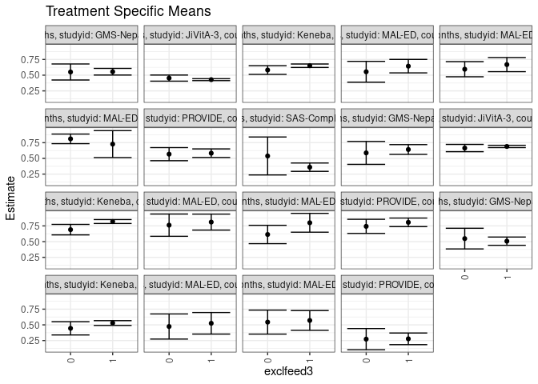

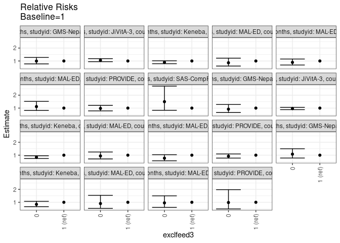

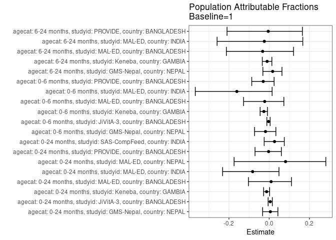

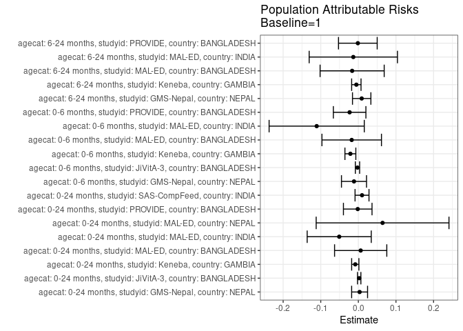

## Results Table

### Parameter: TSM

| agecat | studyid | country | intervention_level | baseline_level | estimate | ci_lower | ci_upper |
| --- | --- | --- | --- | --- | --- | --- | --- |
| 0-24 months | GMS-Nepal | NEPAL | 1 | NA | 0.5547280 | 0.5019438 | 0.6075123 |
| 0-24 months | GMS-Nepal | NEPAL | 0 | NA | 0.5504398 | 0.4229735 | 0.6779061 |
| 0-24 months | JiVitA-3 | BANGLADESH | 1 | NA | 0.4286632 | 0.4133932 | 0.4439332 |
| 0-24 months | JiVitA-3 | BANGLADESH | 0 | NA | 0.4533525 | 0.4048471 | 0.5018579 |
| 0-24 months | Keneba | GAMBIA | 1 | NA | 0.6500061 | 0.6224774 | 0.6775347 |
| 0-24 months | Keneba | GAMBIA | 0 | NA | 0.5818469 | 0.5126879 | 0.6510060 |
| 0-24 months | MAL-ED | BANGLADESH | 1 | NA | 0.6433853 | 0.5361710 | 0.7505996 |
| 0-24 months | MAL-ED | BANGLADESH | 0 | NA | 0.5538727 | 0.3883967 | 0.7193488 |
| 0-24 months | MAL-ED | INDIA | 1 | NA | 0.6681940 | 0.5557734 | 0.7806147 |
| 0-24 months | MAL-ED | INDIA | 0 | NA | 0.5946140 | 0.4742513 | 0.7149767 |
| 0-24 months | MAL-ED | NEPAL | 1 | NA | 0.7272727 | 0.5132170 | 0.9413285 |
| 0-24 months | MAL-ED | NEPAL | 0 | NA | 0.8108108 | 0.7343861 | 0.8872355 |
| 0-24 months | PROVIDE | BANGLADESH | 1 | NA | 0.5828503 | 0.5148707 | 0.6508298 |
| 0-24 months | PROVIDE | BANGLADESH | 0 | NA | 0.5674881 | 0.4635147 | 0.6714614 |
| 0-24 months | SAS-CompFeed | INDIA | 1 | NA | 0.3600000 | 0.2937351 | 0.4262649 |
| 0-24 months | SAS-CompFeed | INDIA | 0 | NA | 0.5384615 | 0.2364546 | 0.8404685 |
| 0-6 months | GMS-Nepal | NEPAL | 1 | NA | 0.6414400 | 0.5637170 | 0.7191630 |
| 0-6 months | GMS-Nepal | NEPAL | 0 | NA | 0.5874914 | 0.4047815 | 0.7702013 |
| 0-6 months | JiVitA-3 | BANGLADESH | 1 | NA | 0.6898319 | 0.6715954 | 0.7080683 |
| 0-6 months | JiVitA-3 | BANGLADESH | 0 | NA | 0.6644831 | 0.6067916 | 0.7221745 |
| 0-6 months | Keneba | GAMBIA | 1 | NA | 0.8196629 | 0.7881655 | 0.8511604 |
| 0-6 months | Keneba | GAMBIA | 0 | NA | 0.6905245 | 0.6072367 | 0.7738124 |
| 0-6 months | MAL-ED | BANGLADESH | 1 | NA | 0.8108108 | 0.6837788 | 0.9378428 |
| 0-6 months | MAL-ED | BANGLADESH | 0 | NA | 0.7619048 | 0.5846570 | 0.9391525 |
| 0-6 months | MAL-ED | INDIA | 1 | NA | 0.8000000 | 0.6503909 | 0.9496091 |
| 0-6 months | MAL-ED | INDIA | 0 | NA | 0.6136364 | 0.4674979 | 0.7597749 |
| 0-6 months | PROVIDE | BANGLADESH | 1 | NA | 0.8070121 | 0.7388425 | 0.8751818 |
| 0-6 months | PROVIDE | BANGLADESH | 0 | NA | 0.7428318 | 0.6304760 | 0.8551875 |
| 6-24 months | GMS-Nepal | NEPAL | 1 | NA | 0.5072618 | 0.4416935 | 0.5728301 |
| 6-24 months | GMS-Nepal | NEPAL | 0 | NA | 0.5480317 | 0.3836108 | 0.7124526 |
| 6-24 months | Keneba | GAMBIA | 1 | NA | 0.5292890 | 0.4914359 | 0.5671420 |
| 6-24 months | Keneba | GAMBIA | 0 | NA | 0.4446928 | 0.3392773 | 0.5501084 |
| 6-24 months | MAL-ED | BANGLADESH | 1 | NA | 0.5250000 | 0.3534413 | 0.6965587 |
| 6-24 months | MAL-ED | BANGLADESH | 0 | NA | 0.4736842 | 0.2738216 | 0.6735468 |
| 6-24 months | MAL-ED | INDIA | 1 | NA | 0.5702504 | 0.4129602 | 0.7275407 |
| 6-24 months | MAL-ED | INDIA | 0 | NA | 0.5438729 | 0.3531170 | 0.7346288 |
| 6-24 months | PROVIDE | BANGLADESH | 1 | NA | 0.2777778 | 0.1853143 | 0.3702413 |
| 6-24 months | PROVIDE | BANGLADESH | 0 | NA | 0.2727273 | 0.1045711 | 0.4408835 |

### Parameter: E(Y)

| agecat | studyid | country | intervention_level | baseline_level | estimate | ci_lower | ci_upper |
| --- | --- | --- | --- | --- | --- | --- | --- |
| 0-24 months | GMS-Nepal | NEPAL | NA | NA | 0.5580448 | 0.5093588 | 0.6067308 |
| 0-24 months | JiVitA-3 | BANGLADESH | NA | NA | 0.4308756 | 0.4161410 | 0.4456101 |
| 0-24 months | Keneba | GAMBIA | NA | NA | 0.6418109 | 0.6160920 | 0.6675299 |
| 0-24 months | MAL-ED | BANGLADESH | NA | NA | 0.6495726 | 0.5607849 | 0.7383604 |
| 0-24 months | MAL-ED | INDIA | NA | NA | 0.6172840 | 0.5340594 | 0.7005085 |
| 0-24 months | MAL-ED | NEPAL | NA | NA | 0.7916667 | 0.7146386 | 0.8686947 |
| 0-24 months | PROVIDE | BANGLADESH | NA | NA | 0.5811688 | 0.5245443 | 0.6377934 |
| 0-24 months | SAS-CompFeed | INDIA | NA | NA | 0.3697479 | 0.3045176 | 0.4349782 |
| 0-6 months | GMS-Nepal | NEPAL | NA | NA | 0.6298343 | 0.5587812 | 0.7008873 |
| 0-6 months | JiVitA-3 | BANGLADESH | NA | NA | 0.6875000 | 0.6700777 | 0.7049223 |
| 0-6 months | Keneba | GAMBIA | NA | NA | 0.7984496 | 0.7683939 | 0.8285053 |
| 0-6 months | MAL-ED | BANGLADESH | NA | NA | 0.7931034 | 0.6894917 | 0.8967152 |
| 0-6 months | MAL-ED | INDIA | NA | NA | 0.6891892 | 0.5810852 | 0.7972932 |
| 0-6 months | PROVIDE | BANGLADESH | NA | NA | 0.7837838 | 0.7252863 | 0.8422812 |
| 6-24 months | GMS-Nepal | NEPAL | NA | NA | 0.5161290 | 0.4555456 | 0.5767125 |
| 6-24 months | Keneba | GAMBIA | NA | NA | 0.5239207 | 0.4881434 | 0.5596979 |
| 6-24 months | MAL-ED | BANGLADESH | NA | NA | 0.5084746 | 0.3754416 | 0.6415076 |
| 6-24 months | MAL-ED | INDIA | NA | NA | 0.5568182 | 0.4384773 | 0.6751591 |
| 6-24 months | PROVIDE | BANGLADESH | NA | NA | 0.2764228 | 0.1950773 | 0.3577682 |

### Parameter: RR

| agecat | studyid | country | intervention_level | baseline_level | estimate | ci_lower | ci_upper |
| --- | --- | --- | --- | --- | --- | --- | --- |
| 0-24 months | GMS-Nepal | NEPAL | 1 | 1 | 1.0000000 | 1.0000000 | 1.0000000 |
| 0-24 months | GMS-Nepal | NEPAL | 0 | 1 | 0.9922697 | 0.7722239 | 1.2750179 |
| 0-24 months | JiVitA-3 | BANGLADESH | 1 | 1 | 1.0000000 | 1.0000000 | 1.0000000 |
| 0-24 months | JiVitA-3 | BANGLADESH | 0 | 1 | 1.0575961 | 0.9462051 | 1.1821004 |
| 0-24 months | Keneba | GAMBIA | 1 | 1 | 1.0000000 | 1.0000000 | 1.0000000 |
| 0-24 months | Keneba | GAMBIA | 0 | 1 | 0.8951408 | 0.7896248 | 1.0147565 |
| 0-24 months | MAL-ED | BANGLADESH | 1 | 1 | 1.0000000 | 1.0000000 | 1.0000000 |
| 0-24 months | MAL-ED | BANGLADESH | 0 | 1 | 0.8608725 | 0.6078430 | 1.2192318 |
| 0-24 months | MAL-ED | INDIA | 1 | 1 | 1.0000000 | 1.0000000 | 1.0000000 |
| 0-24 months | MAL-ED | INDIA | 0 | 1 | 0.8898823 | 0.6871080 | 1.1524979 |
| 0-24 months | MAL-ED | NEPAL | 1 | 1 | 1.0000000 | 1.0000000 | 1.0000000 |
| 0-24 months | MAL-ED | NEPAL | 0 | 1 | 1.1148649 | 0.8180289 | 1.5194129 |
| 0-24 months | PROVIDE | BANGLADESH | 1 | 1 | 1.0000000 | 1.0000000 | 1.0000000 |
| 0-24 months | PROVIDE | BANGLADESH | 0 | 1 | 0.9736430 | 0.7830945 | 1.2105571 |
| 0-24 months | SAS-CompFeed | INDIA | 1 | 1 | 1.0000000 | 1.0000000 | 1.0000000 |
| 0-24 months | SAS-CompFeed | INDIA | 0 | 1 | 1.4957265 | 0.8288715 | 2.6990889 |
| 0-6 months | GMS-Nepal | NEPAL | 1 | 1 | 1.0000000 | 1.0000000 | 1.0000000 |
| 0-6 months | GMS-Nepal | NEPAL | 0 | 1 | 0.9158945 | 0.6558008 | 1.2791427 |
| 0-6 months | JiVitA-3 | BANGLADESH | 1 | 1 | 1.0000000 | 1.0000000 | 1.0000000 |
| 0-6 months | JiVitA-3 | BANGLADESH | 0 | 1 | 0.9632537 | 0.8798957 | 1.0545086 |
| 0-6 months | Keneba | GAMBIA | 1 | 1 | 1.0000000 | 1.0000000 | 1.0000000 |
| 0-6 months | Keneba | GAMBIA | 0 | 1 | 0.8424494 | 0.7429767 | 0.9552399 |
| 0-6 months | MAL-ED | BANGLADESH | 1 | 1 | 1.0000000 | 1.0000000 | 1.0000000 |
| 0-6 months | MAL-ED | BANGLADESH | 0 | 1 | 0.9396825 | 0.7098559 | 1.2439191 |
| 0-6 months | MAL-ED | INDIA | 1 | 1 | 1.0000000 | 1.0000000 | 1.0000000 |
| 0-6 months | MAL-ED | INDIA | 0 | 1 | 0.7670455 | 0.5666415 | 1.0383263 |
| 0-6 months | PROVIDE | BANGLADESH | 1 | 1 | 1.0000000 | 1.0000000 | 1.0000000 |
| 0-6 months | PROVIDE | BANGLADESH | 0 | 1 | 0.9204716 | 0.7737976 | 1.0949478 |
| 6-24 months | GMS-Nepal | NEPAL | 1 | 1 | 1.0000000 | 1.0000000 | 1.0000000 |
| 6-24 months | GMS-Nepal | NEPAL | 0 | 1 | 1.0803725 | 0.7791245 | 1.4980978 |
| 6-24 months | Keneba | GAMBIA | 1 | 1 | 1.0000000 | 1.0000000 | 1.0000000 |
| 6-24 months | Keneba | GAMBIA | 0 | 1 | 0.8401702 | 0.6561439 | 1.0758098 |
| 6-24 months | MAL-ED | BANGLADESH | 1 | 1 | 1.0000000 | 1.0000000 | 1.0000000 |
| 6-24 months | MAL-ED | BANGLADESH | 0 | 1 | 0.9022556 | 0.5291159 | 1.5385386 |
| 6-24 months | MAL-ED | INDIA | 1 | 1 | 1.0000000 | 1.0000000 | 1.0000000 |
| 6-24 months | MAL-ED | INDIA | 0 | 1 | 0.9537439 | 0.6064702 | 1.4998717 |
| 6-24 months | PROVIDE | BANGLADESH | 1 | 1 | 1.0000000 | 1.0000000 | 1.0000000 |
| 6-24 months | PROVIDE | BANGLADESH | 0 | 1 | 0.9818182 | 0.4873998 | 1.9777746 |

### Parameter: PAR

| agecat | studyid | country | intervention_level | baseline_level | estimate | ci_lower | ci_upper |
| --- | --- | --- | --- | --- | --- | --- | --- |
| 0-24 months | GMS-Nepal | NEPAL | 1 | NA | 0.0033168 | -0.0178542 | 0.0244877 |
| 0-24 months | JiVitA-3 | BANGLADESH | 1 | NA | 0.0022124 | -0.0022737 | 0.0066984 |
| 0-24 months | Keneba | GAMBIA | 1 | NA | -0.0081952 | -0.0178122 | 0.0014219 |
| 0-24 months | MAL-ED | BANGLADESH | 1 | NA | 0.0061874 | -0.0632524 | 0.0756271 |
| 0-24 months | MAL-ED | INDIA | 1 | NA | -0.0509101 | -0.1361223 | 0.0343021 |
| 0-24 months | MAL-ED | NEPAL | 1 | NA | 0.0643939 | -0.1121822 | 0.2409701 |
| 0-24 months | PROVIDE | BANGLADESH | 1 | NA | -0.0016814 | -0.0396905 | 0.0363276 |
| 0-24 months | SAS-CompFeed | INDIA | 1 | NA | 0.0097479 | -0.0087899 | 0.0282857 |
| 0-6 months | GMS-Nepal | NEPAL | 1 | NA | -0.0116057 | -0.0449106 | 0.0216991 |
| 0-6 months | JiVitA-3 | BANGLADESH | 1 | NA | -0.0023319 | -0.0080371 | 0.0033733 |
| 0-6 months | Keneba | GAMBIA | 1 | NA | -0.0212133 | -0.0357077 | -0.0067190 |
| 0-6 months | MAL-ED | BANGLADESH | 1 | NA | -0.0177074 | -0.0968466 | 0.0614319 |
| 0-6 months | MAL-ED | INDIA | 1 | NA | -0.1108108 | -0.2373338 | 0.0157122 |
| 0-6 months | PROVIDE | BANGLADESH | 1 | NA | -0.0232284 | -0.0665086 | 0.0200519 |
| 6-24 months | GMS-Nepal | NEPAL | 1 | NA | 0.0088672 | -0.0155890 | 0.0333235 |
| 6-24 months | Keneba | GAMBIA | 1 | NA | -0.0053683 | -0.0178387 | 0.0071021 |
| 6-24 months | MAL-ED | BANGLADESH | 1 | NA | -0.0165254 | -0.1017525 | 0.0687016 |
| 6-24 months | MAL-ED | INDIA | 1 | NA | -0.0134323 | -0.1308385 | 0.1039739 |
| 6-24 months | PROVIDE | BANGLADESH | 1 | NA | -0.0013550 | -0.0528032 | 0.0500932 |

### Parameter: PAF

| agecat | studyid | country | intervention_level | baseline_level | estimate | ci_lower | ci_upper |
| --- | --- | --- | --- | --- | --- | --- | --- |
| 0-24 months | GMS-Nepal | NEPAL | 1 | NA | 0.0059436 | -0.0327226 | 0.0431621 |
| 0-24 months | JiVitA-3 | BANGLADESH | 1 | NA | 0.0051346 | -0.0053276 | 0.0154880 |
| 0-24 months | Keneba | GAMBIA | 1 | NA | -0.0127688 | -0.0278693 | 0.0021098 |
| 0-24 months | MAL-ED | BANGLADESH | 1 | NA | 0.0095253 | -0.1032239 | 0.1107515 |
| 0-24 months | MAL-ED | INDIA | 1 | NA | -0.0824743 | -0.2315851 | 0.0485833 |
| 0-24 months | MAL-ED | NEPAL | 1 | NA | 0.0813397 | -0.1745047 | 0.2814531 |
| 0-24 months | PROVIDE | BANGLADESH | 1 | NA | -0.0028932 | -0.0704766 | 0.0604234 |
| 0-24 months | SAS-CompFeed | INDIA | 1 | NA | 0.0263636 | -0.0248925 | 0.0750564 |
| 0-6 months | GMS-Nepal | NEPAL | 1 | NA | -0.0184267 | -0.0727992 | 0.0331901 |
| 0-6 months | JiVitA-3 | BANGLADESH | 1 | NA | -0.0033918 | -0.0117267 | 0.0048744 |
| 0-6 months | Keneba | GAMBIA | 1 | NA | -0.0265682 | -0.0450518 | -0.0084115 |
| 0-6 months | MAL-ED | BANGLADESH | 1 | NA | -0.0223267 | -0.1273587 | 0.0729199 |
| 0-6 months | MAL-ED | INDIA | 1 | NA | -0.1607843 | -0.3673319 | 0.0145624 |
| 0-6 months | PROVIDE | BANGLADESH | 1 | NA | -0.0296362 | -0.0867078 | 0.0244382 |
| 6-24 months | GMS-Nepal | NEPAL | 1 | NA | 0.0171802 | -0.0314315 | 0.0635009 |
| 6-24 months | Keneba | GAMBIA | 1 | NA | -0.0102464 | -0.0343438 | 0.0132896 |
| 6-24 months | MAL-ED | BANGLADESH | 1 | NA | -0.0325000 | -0.2127605 | 0.1209672 |
| 6-24 months | MAL-ED | INDIA | 1 | NA | -0.0241232 | -0.2590172 | 0.1669467 |
| 6-24 months | PROVIDE | BANGLADESH | 1 | NA | -0.0049020 | -0.2095297 | 0.1651070 |